# Markdown Report: RNA-seq Analysis

Mireia Gangonells

2023-03-13

```r
if(!require(BiocManager)){
install.packages("BiocManager", dep=TRUE)
}
installifnot <- function (pckgName, BioC=TRUE){
if(BioC){
if(!require(pckgName, character.only=TRUE)){
BiocManager::install(pckgName)
}
}else{
if(!require(pckgName, character.only=TRUE)){
install.packages(pckgName, dep=TRUE)
}
}
}
libraries<- c("limma","edgeR","Glimma","Mus.musculus")
for(i in libraries){
print(i)
installifnot(i)
library(i, character.only = TRUE, quietly = TRUE)
}
```

```
## [1] "limma"
```

```
## [1] "edgeR"
```

```
## [1] "Glimma"
```

```
## [1] "Mus.musculus"
```

```r
libraries <- c("RColorBrewer","gplots")
for(i in libraries){
installifnot(i, BioC = FALSE)
library(i, character.only = TRUE, quietly = TRUE)
}
```

**1. Quina pregunta biológica es vol contestar (organisme, teixit, material analitzat, …). Explica el disseny experimental (factors, condició experimental, número rèpliques, pool/no pool, …).**

ORGANISME: MUS MUSCULUS; M.BIOLOGIC: mRNA

Les dades es componen per 12 mostres analitzades, 4 com a control, 4 amb dades que s han pres 2 hores després de l’intervenció i unes últimes 4 amb informació 24 hores després (a més d’una primera variable identificadora, per tant treballarem amb un factor a tres nivells amb 4 rèpliques (i per tant equilibrat).

**2. Importa els counts normalitzats del fitxer GSE116583_transplant.am.htseq.all.rpkm.txt i crea un objecte DGlist, assignant en els slots convenients els counts i els grups de mostres de l’experiment.**

```r
mydata<-read.delim2("GSE116583_transplant.am.htseq.all.rpkm.txt",
header=T, sep="\t" ,dec=".")
x<- DGEList(counts=mydata[, 2:13 ], group=rep(1:3,each=4))
rownames(x) <- mydata[,1]
```

```r
group<-x$samples$group
```

```r
class(x)
```

```
## [1] "DGEList"
## attr(,"package")
## [1] "edgeR"
```

```r
dim(x)
```

```
## [1] 43430    12
```

```r
names(x)
```

```
## [1] "counts"  "samples"
```

```r
str(x)
```

```
## Formal class 'DGEList' [package "edgeR"] with 1 slot
##   ..@ .Data:List of 2
##   .. ..$ : num [1:43430, 1:12] 66.56726 0 2.40761 0 0.00985 ...
##   .. .. ..- attr(*, "dimnames")=List of 2
##   .. .. .. ..$ : chr [1:43430] "ENSMUSG00000000001" "ENSMUSG00000000003" "ENSMUSG00000000028" "ENSMUSG00000000031" ...
##   .. .. .. ..$ : chr [1:12] "N01_AM_Naive_01" "N02_AM_Naive_02" "N03_AM_Naive_03" "N04_AM_Naive_04" ...
##   .. ..$ :'data.frame':  12 obs. of  3 variables:
##   .. .. ..$ group       : Factor w/ 3 levels "1","2","3": 1 1 1 1 2 2 2 2 3 3 ...
##   .. .. ..$ lib.size    : num [1:12] 239577 238885 240952 248650 243913 ...
##   .. .. ..$ norm.factors: num [1:12] 1 1 1 1 1 1 1 1 1 1 ...
##   ..$ names: chr [1:2] "counts" "samples"
```

**3. Filtra els gens poc expressats (rpkm) de tal manera que els gens que quedaran han de tenir una expressió superior o igual a 1 en almenys el 50% de les mostres. Actualitzat els counts filtrats amb log rpkm que serà la transformació que es mantindrà a partir d’ara.**

```r
cpm <- cpm(x)
lcpm <- cpm(x, log = TRUE)
```

```r
# Only keep genes that fit the criteria
keep.exprs <- rowSums(cpm >= 1) >= 6
#6=50% de 12 que és el nombre de mostres
x <- x[keep.exprs, , keep.lib.sizes = FALSE]
dim(x)
```

```
## [1] 13722    12
```

```r
#RPKM atualitzats
cpm <- cpm(x)
lcpm <- cpm(x, log = TRUE)
```

**4. Anotar els gens especificant els “genes symbol”, el cromosoma i l’EntrezID a partir de la base de dades Mus.musculus de bioconductor. Has trobat gens duplicats? Recorda d’assignar els gens al slot adient del objecte DGEList.**

```r
geneid <- rownames(x)
genes <- select(Mus.musculus, keys = rownames(x),
                columns = c("SYMBOL", "TXCHROM","ENTREZID"),
                keytype = "ENSEMBL")
#Nombre d'obserbacions i variables abans d'eliminar duplicats
genes1<-genes
dim(genes1)
```

```
## [1] 13797     4
```

```r
#Nombre d'obserbacions i variables després
genes <- genes[!duplicated(genes$ENTREZID), ]
dim(genes)
```

```
## [1] 11811     4
```

Observem que les dimensions són diferents abans i després d’ eliminar els repetits, per tant si que hi havia duplicats.

**5. Visualitza la distribució de l’expressió dels gens en les 12 mostres. Comenta els resultats obtinguts.**

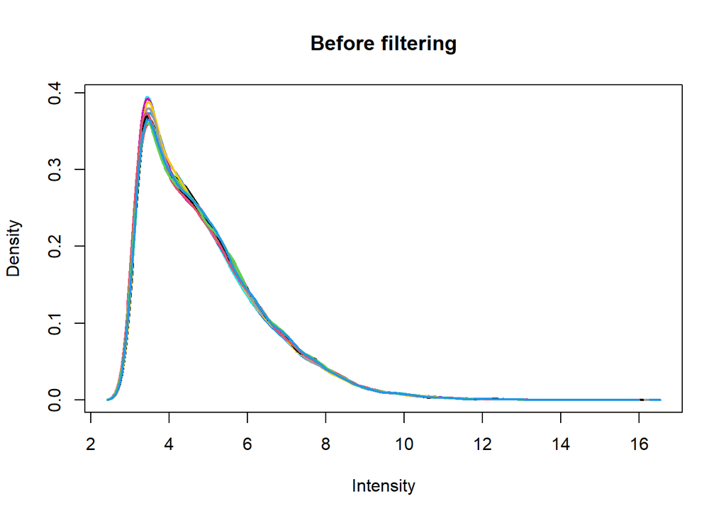

```r
# Visualize distribution of gene expression levels
plotDensities(lcpm, legend = FALSE, main = "Before filtering")
abline(v = 0, lty = 3)
```

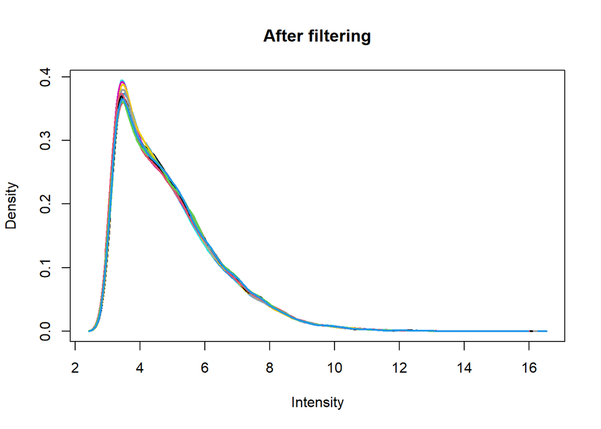

```r
lcpm <- cpm(x, log=TRUE)
plotDensities(lcpm, legend = FALSE, main = "After filtering")
abline(v = 0, lty = 3)
```

Les distribucións semblen ser bastant semblants a primera vista, cap destaca, peró sique s’observa com la densitat disminueix a mesura que l’intensitat creix després d’arribar al seu màxim quan l’intensitat es troba prop de 4.

**6. Representa en dimensió reduïda (MDS) les mostres. Comenta els resultats obtinguts.**

```r
# Visualize sample relationships with multidimensional scaling (MDS).
library("RColorBrewer")
samplenames <- substring(colnames(x), 12, nchar(colnames(x)))
samplenames
```

```
##  [1] "e_01"    "e_02"    "e_03"    "e_04"    "_02H_01" "_02H_02" "_02H_03"
##  [8] "_02H_04" "_24H_01" "_24H_02" "_24H_03" "_24H_04"
```

```r
colnames(x) <- samplenames
x$samples$group <- group
lane <- as.factor(rep(c("L004", "L006", "L008"), c(4, 4, 4)))
x$samples$lane <- lane
x$samples
```

```
##         group lib.size norm.factors lane
## e_01        1 238700.2            1 L004
## e_02        1 238094.8            1 L004
## e_03        1 240101.1            1 L004
## e_04        1 247647.4            1 L004
## _02H_01     2 242860.5            1 L006
## _02H_02     2 243162.4            1 L006
## _02H_03     2 246965.8            1 L006
## _02H_04     2 243125.8            1 L006
## _24H_01     3 248829.6            1 L008
## _24H_02     3 249898.0            1 L008
## _24H_03     3 243180.5            1 L008
## _24H_04     3 246208.1            1 L008
```

```r
col.group <- group
levels(col.group) <- brewer.pal(nlevels(col.group), "Set1")
col.group <- as.character(col.group)
lane
```

```
##  [1] L004 L004 L004 L004 L006 L006 L006 L006 L008 L008 L008 L008
## Levels: L004 L006 L008
```

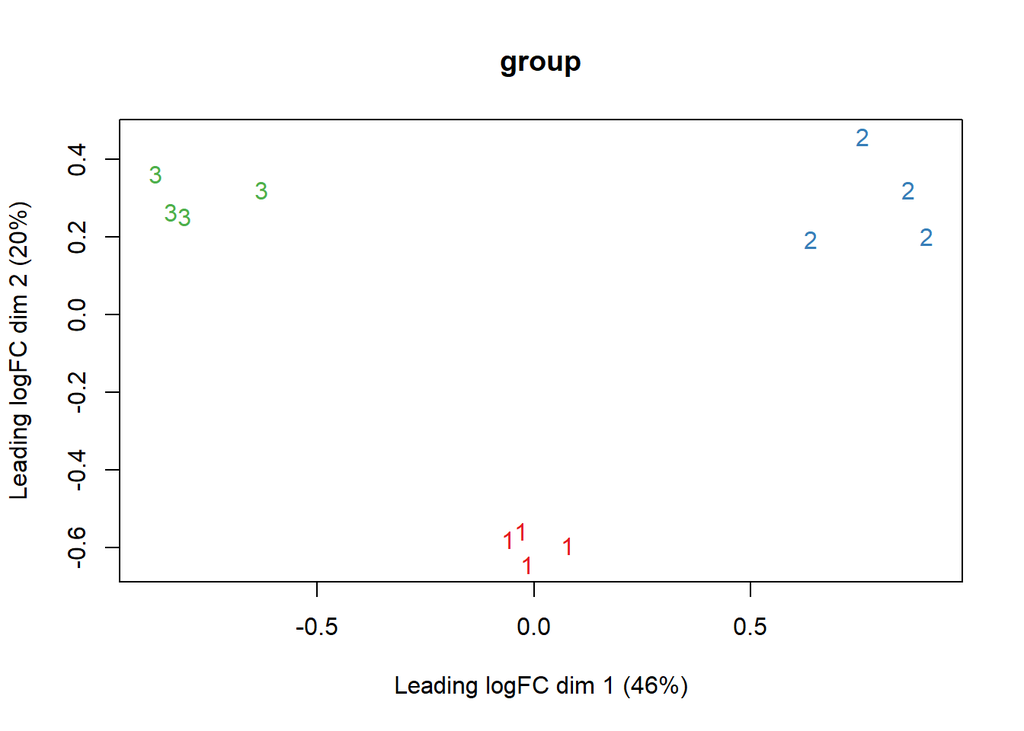

```r
col.lane <- lane
levels(col.lane) <- brewer.pal(nlevels(col.lane), "Set2")
col.lane <- as.character(col.lane)
plotMDS(lcpm, labels = group, col = col.group,
main = "group")
```

Es pot observar fàcilment en aquest gràfic que hi ha similituds dins del grup però diferències notables entre aquests a la vegada, sent així fàcil distingr-los.

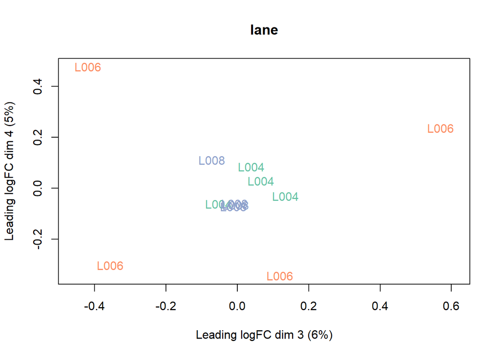

```r
plotMDS(lcpm, labels = lane, col = col.lane, dim = c(3, 4),
main = "lane")
```

**7. Estem interessats en totes les comparacions 2 a 2. Defineix la matriu de disseny i els contrastos.**

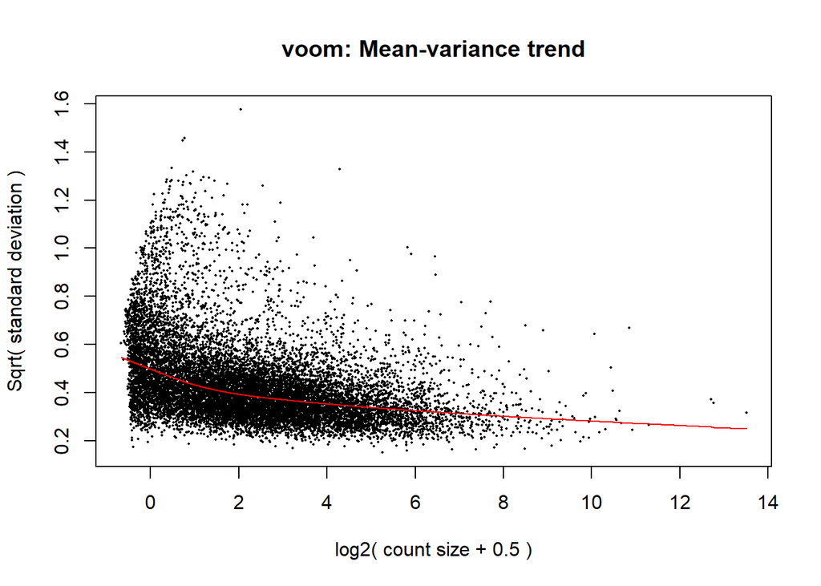

```r
# Construct linear model ---------------------------------------------
group<-as.factor(rep(c("Con","Dues","Dia"),c(4,4,4)))
design <- model.matrix(~0 + group)
colnames(design) <- gsub("group", "", colnames(design))
contr.matrix <- makeContrasts(dia_Dues = Dia - Dues,
Dia_Con = Dia - Con,
Con_Dues = Con - Dues,
levels = colnames(design))

v <- voom(x, design, plot=TRUE)
```

**8. Ajusta el model lineal aplicant les transformacions necessàries.**

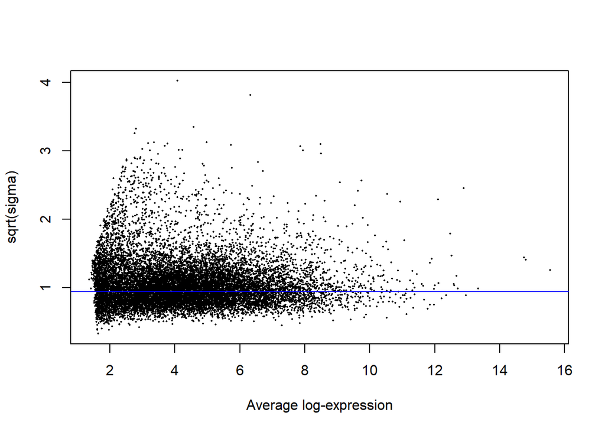

```r
vfit <- lmFit(v, design)
vfit <- contrasts.fit(vfit, contrasts=contr.matrix)
efit <- eBayes(vfit)
plotSA(efit)
```

**9. Obté la taula d’expressió diferencial de cada contrast. Mostrant els top 10 gens d’acord amb el p-valor ajustat.**

```r
# Tabulate the results
summary(decideTests(efit))
```

```
##        dia_Dues Dia_Con Con_Dues
## Down       2725    2847     1599
## NotSig     7451    8169     9294
## Up         3546    2706     2829
```

```r
tfit <- treat(vfit, lfc = 1)
dt <- decideTests(tfit)
```

```r
summary(dt)
```

```
##        dia_Dues Dia_Con Con_Dues
## Down         88      18       41
## NotSig    13317   13504    13681
## Up          317     200        0
```

```r
# Create a venn diagram of the results.
head(dt)
```

```
## TestResults matrix
##                     Contrasts
##                      dia_Dues Dia_Con Con_Dues
##   ENSMUSG00000000001        0       0        0
##   ENSMUSG00000000028        1       1        0
##   ENSMUSG00000000056        0       0        0
##   ENSMUSG00000000058        0       0        0
##   ENSMUSG00000000078        0       0        0
##   ENSMUSG00000000085        0       0        0
```

```r
#Top 10 gens d'acord amb el p-valor ajustat
topTreat(tfit, coef = 1, n = 10) #diavsdosH
```

```
##                       logFC  AveExpr        t      P.Value    adj.P.Val
## ENSMUSG00000040204 3.445929 5.207106 32.05529 4.825940e-13 6.622155e-09
## ENSMUSG00000020649 3.166945 6.139235 22.71172 2.534799e-11 1.739125e-07
## ENSMUSG00000030978 2.642537 6.745659 21.54567 4.625296e-11 1.987802e-07
## ENSMUSG00000036768 2.811848 4.820975 21.12410 5.794496e-11 1.987802e-07
## ENSMUSG00000001228 2.955966 4.032391 19.11939 1.800095e-10 4.940180e-07
## ENSMUSG00000005410 2.823215 6.064939 18.51564 2.588683e-10 5.920318e-07
## ENSMUSG00000027306 2.566556 4.645195 18.14832 3.246618e-10 6.364299e-07
## ENSMUSG00000005470 2.797784 5.502967 17.68891 4.337220e-10 7.439416e-07
## ENSMUSG00000020914 2.833512 6.155238 17.41080 5.185976e-10 7.906885e-07
## ENSMUSG00000002068 2.515454 3.769630 17.07817 6.443374e-10 8.841598e-07
```

```r
topTreat(tfit, coef = 2, n = 10) #diavsNaive
```

```
##                       logFC  AveExpr        t      P.Value    adj.P.Val
## ENSMUSG00000040204 2.769096 5.207106 24.59812 1.016328e-11 1.394605e-07
## ENSMUSG00000020649 2.495247 6.139235 16.32009 1.073187e-09 7.363135e-06
## ENSMUSG00000030978 2.158821 6.745659 15.59211 1.788709e-09 8.181553e-06
## ENSMUSG00000001228 2.373001 4.032391 14.66126 3.552242e-09 1.013778e-05
## ENSMUSG00000036768 2.181965 4.820975 14.60969 3.693990e-09 1.013778e-05
## ENSMUSG00000005410 2.333608 6.064939 13.93613 6.233289e-09 1.425553e-05
## ENSMUSG00000027306 2.136921 4.645195 13.73291 7.331557e-09 1.437195e-05
## ENSMUSG00000019992 2.271394 3.627404 13.01715 1.321575e-08 2.266832e-05
## ENSMUSG00000002068 2.050522 3.769630 12.74790 1.661766e-08 2.533639e-05
## ENSMUSG00000026683 2.002456 3.638273 12.41254 2.223752e-08 2.730422e-05
```

```r
topTreat(tfit, coef = 3, n = 10) #NaivevsdosH
```

```
##                        logFC  AveExpr         t      P.Value    adj.P.Val
## ENSMUSG00000069996 -4.560082 2.795616 -15.30328 2.218132e-09 3.043720e-05
## ENSMUSG00000049404 -3.053227 4.593886 -13.08196 1.252006e-08 7.493051e-05
## ENSMUSG00000094627 -4.993899 3.189964 -12.77701 1.638183e-08 7.493051e-05
## ENSMUSG00000058126 -4.928973 3.681153 -12.11272 2.932219e-08 9.766699e-05
## ENSMUSG00000039114 -3.082451 2.574529 -11.88797 3.558774e-08 9.766699e-05
## ENSMUSG00000063696 -5.940404 4.006164 -11.35880 5.956885e-08 1.268319e-04
## ENSMUSG00000078183 -4.489355 2.886259 -11.25437 6.470074e-08 1.268319e-04
## ENSMUSG00000083773 -6.432346 3.758417 -11.04855 8.089311e-08 1.387519e-04
## ENSMUSG00000095597 -5.181995 3.210331 -10.50150 1.366785e-07 2.083892e-04
## ENSMUSG00000062353 -6.736705 4.494622 -10.18378 1.940450e-07 2.662685e-04
```

```r
topcontrvsdos <-topTreat(tfit, coef = 3, n = Inf)
```

**10. Representa els volcano plots dels contrastos corresponents al grup control contra els trasplantaments a 2 i 24 hores. Remarcant els top 10 gens en cadascun d’aquests contrastos.**

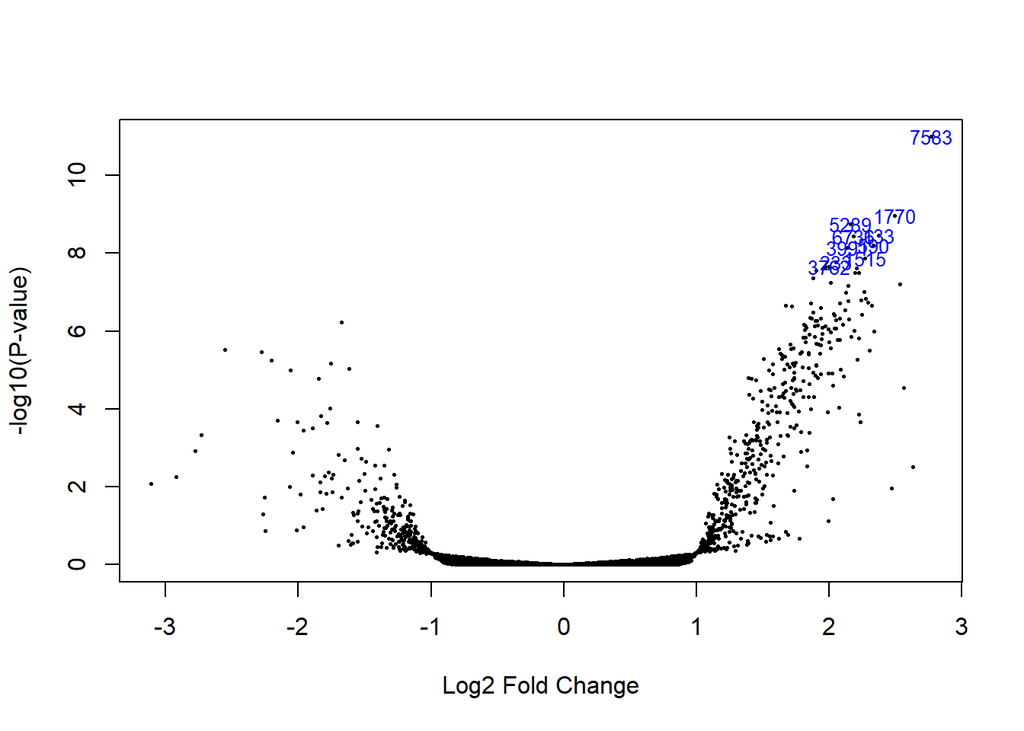

```r
volcanoplot(tfit, coef = 2, style = "p-value", highlight = 10, names = tfit$genes$SYMBOL, hl.col="blue")
```

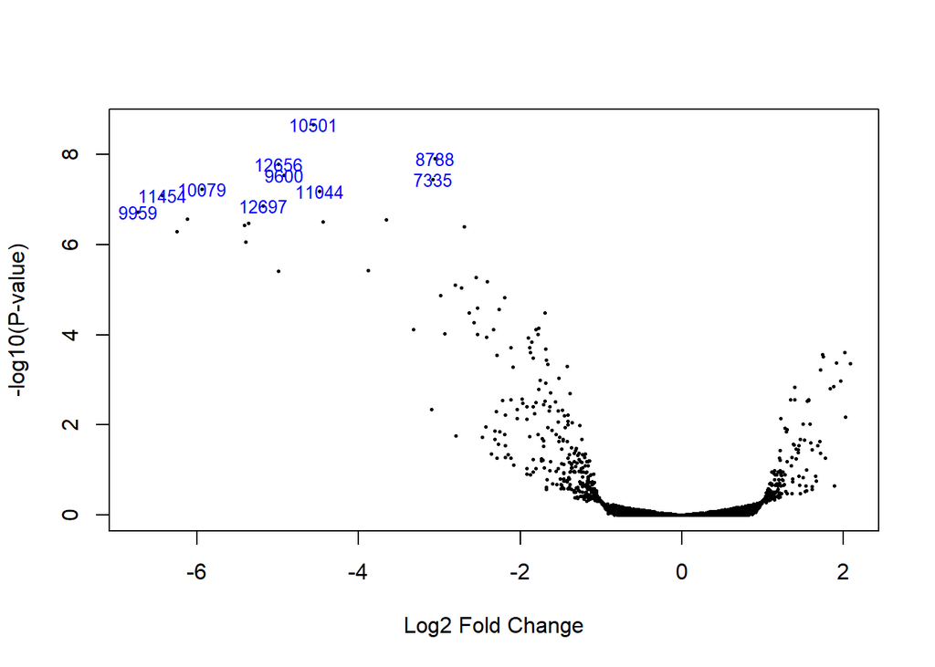

```r
volcanoplot(tfit, coef = 3, style = "p-value", highlight = 10, names = tfit$genes$SYMBOL, hl.col="blue")
```

```r
glMDPlot(tfit, coef = 1, status = dt, main = colnames(tfit)[1],
side.main = "ENTREZID", counts = x$counts, groups = group,
launch = TRUE)
```

**12. Fes un anàlisi d’enriquiment del contrast entre grup control i els trasplantats a 2 hores de manera similar a la pràctica fet a classe. Recorda d’usar el EntrezID com referència per fer l’enriquiment.**

(No em deixa passar el document a html pel link o per problemes que no consegueixo arreclar, per tant el deixo comentat per poder entregar un pdf i al Rmd també entregat dins del zip estarà descomentat per poder observar bé els resultats d’aquest exercici, ja que al Rdm sí que funciona.)

```r
#load(url("http://bioinf.wehi.edu.au/software/MSigDB/mouse_c2_v5p1.rdata"))
#idx <- ids2indices(Mm.c2,id=v$genes$ENTREZID)

#cam.contvsdos <- camera(v,idx,design,contrast=contr.matrix[,3])
#head(cam.contvsdos,5)

#barcodeplot(efit$t[,3], index=idx$LIM_MAMMARY_LUMINAL_MATURE_UP,
#main="NAIVEvs2")

#barcodeplot(efit$t[,3], index=idx$LIM_MAMMARY_LUMINAL_MATURE_DN,
#main="NAIVEvs2")
```